[figure not shown]

# WS2 WireFrame IBK - Preparación de datos

## Resumen:

El objetivo de este desarrollo es plantear un caso de uso mockup cercano al de pricing PP para ejemplificar como se puede abordar en un entorno de desarrollo.

Este primer notebook aborda la carga y transformaciones de datos para el caso mockup

## Tabla de contenidos

1. Carga de datos y librerías
2. Limpieza de datos
3. Análisis univariado
4. Ejemplo de segmentación RFM
5. Codificación de variables categóricas
6. Tabla final

## Carga de datos y librerías

(back to top)

```python
import os, boto3
import sagemaker
from sagemaker.session import s3_input, Session
from joblib import dump, load
import pandas as pd, numpy as np
from datetime import datetime
from sklearn.preprocessing import MinMaxScaler,OneHotEncoder
from sklearn.model_selection import train_test_split
from sklearn.ensemble import RandomForestRegressor
from sklearn.metrics import r2_score,mean_absolute_error,mean_squared_error,explained_variance_score
import requests, io, sys
import matplotlib.pyplot as plt
import seaborn as sns

sns.set()

client = boto3.client('s3')
```

Conjunto de datos utilizado: [Loan dataset](https://www.kaggle.com/prashanthsri12/bank-loan-interest-rate-dataset)

```python
df = pd.read_csv('data/loan_data_train.csv')
# subidad de dataframe sin procesamiento para processing job
df.to_csv('s3://sagemaker-us-east-1-189229688351/IBK-mockup/data/loan_data_train.csv')

# df_test = pd.read_csv('data/loan_data_test.csv')
```

```python
df.head()
```

|  | ID | Amount.Requested | Amount.Funded.By.Investors | Interest.Rate | Loan.Length | Loan.Purpose | Debt.To.Income.Ratio | State | Home.Ownership | Monthly.Income | FICO.Range | Open.CREDIT.Lines | Revolving.CREDIT.Balance | Inquiries.in.the.Last.6.Months | Employment.Length |
| --- | --- | --- | --- | --- | --- | --- | --- | --- | --- | --- | --- | --- | --- | --- | --- |
| 0 | 79542.0 | 25000 | 25000 | 18.49% | 60 months | debt_consolidation | 27.56% | VA | MORTGAGE | 8606.56 | 720-724 | 11 | 15210 | 3.0 | 5 years |
| 1 | 75473.0 | 19750 | 19750 | 17.27% | 60 months | debt_consolidation | 13.39% | NY | MORTGAGE | 6737.50 | 710-714 | 14 | 19070 | 3.0 | 4 years |
| 2 | 67265.0 | 2100 | 2100 | 14.33% | 36 months | major_purchase | 3.50% | LA | OWN | 1000.00 | 690-694 | 13 | 893 | 1.0 | < 1 year |
| 3 | 80167.0 | 28000 | 28000 | 16.29% | 36 months | credit_card | 19.62% | NV | MORTGAGE | 7083.33 | 710-714 | 12 | 38194 | 1.0 | 10+ years |
| 4 | 17240.0 | 24250 | 17431.82 | 12.23% | 60 months | credit_card | 23.79% | OH | MORTGAGE | 5833.33 | 730-734 | 6 | 31061 | 2.0 | 10+ years |

```python
df.shape
```

```
(2200, 15)
```

```python
df.info()
```

```
<class 'pandas.core.frame.DataFrame'>
RangeIndex: 2200 entries, 0 to 2199
Data columns (total 15 columns):
 #   Column                          Non-Null Count  Dtype
---  ------                          --------------  -----
 0   ID                              2199 non-null   float64
 1   Amount.Requested                2199 non-null   object
 2   Amount.Funded.By.Investors      2199 non-null   object
 3   Interest.Rate                   2200 non-null   object
 4   Loan.Length                     2199 non-null   object
 5   Loan.Purpose                    2199 non-null   object
 6   Debt.To.Income.Ratio            2199 non-null   object
 7   State                           2199 non-null   object
 8   Home.Ownership                  2199 non-null   object
 9   Monthly.Income                  2197 non-null   float64
 10  FICO.Range                      2200 non-null   object
 11  Open.CREDIT.Lines               2196 non-null   object
 12  Revolving.CREDIT.Balance        2197 non-null   object
 13  Inquiries.in.the.Last.6.Months  2197 non-null   float64
 14  Employment.Length               2131 non-null   object
dtypes: float64(3), object(12)
memory usage: 257.9+ KB
```

```python
df.isnull().sum()
```

```
ID                                 1
Amount.Requested                   1
Amount.Funded.By.Investors         1
Interest.Rate                      0
Loan.Length                        1
Loan.Purpose                       1
Debt.To.Income.Ratio               1
State                              1
Home.Ownership                     1
Monthly.Income                     3
FICO.Range                         0
Open.CREDIT.Lines                  4
Revolving.CREDIT.Balance           3
Inquiries.in.the.Last.6.Months     3
Employment.Length                 69
dtype: int64
```

# Limpieza de datos

(back to top)

Definición de tipos de datos para tipos de variables

```python
df['ID'] = df['ID'].astype('str').str.split('.').str[0]
```

### Categorical & numeric

```python
# Dividing the columns in the dataset in to numeric and categorical attributes.
cols = set(df.columns)
cols_categorical = set(['Loan.Purpose','State','Home.Ownership','FICO.Range'])
cols_numeric = list(cols - cols_categorical)
```

```python
cols_numeric
```

```
['Interest.Rate',
 'Debt.To.Income.Ratio',
 'Open.CREDIT.Lines',
 'Amount.Funded.By.Investors',
 'Employment.Length',
 'Amount.Requested',
 'ID',
 'Loan.Length',
 'Monthly.Income',
 'Inquiries.in.the.Last.6.Months',
 'Revolving.CREDIT.Balance']
```

```python
# eliminar valores nulos de columnas numéricas
df.dropna(subset=cols_numeric,inplace=True)
```

```python
for x in cols_categorical:
    df[x] = df[x].astype('category')

df.info()
```

```
<class 'pandas.core.frame.DataFrame'>
Int64Index: 2120 entries, 0 to 2199
Data columns (total 15 columns):
 #   Column                          Non-Null Count  Dtype
---  ------                          --------------  -----
 0   ID                              2120 non-null   object
 1   Amount.Requested                2120 non-null   object
 2   Amount.Funded.By.Investors      2120 non-null   object
 3   Interest.Rate                   2120 non-null   object
 4   Loan.Length                     2120 non-null   object
 5   Loan.Purpose                    2119 non-null   category
 6   Debt.To.Income.Ratio            2120 non-null   object
 7   State                           2120 non-null   category
 8   Home.Ownership                  2119 non-null   category
 9   Monthly.Income                  2120 non-null   float64
 10  FICO.Range                      2120 non-null   category
 11  Open.CREDIT.Lines               2120 non-null   object
 12  Revolving.CREDIT.Balance        2120 non-null   object
 13  Inquiries.in.the.Last.6.Months  2120 non-null   float64
 14  Employment.Length               2120 non-null   object
dtypes: category(4), float64(2), object(9)
memory usage: 211.1+ KB
```

```python
# Pasar algunas variables string a números
df['Interest.Rate'] = df['Interest.Rate'].str.replace(r'%', r'').astype('float') / 100.0
df['Loan.Length'] = df['Loan.Length'].str.split(' ').str[0]
df['Debt.To.Income.Ratio'] = df['Debt.To.Income.Ratio'].str.replace(r'%', r'').astype('float') / 100.0
df['Employment.Length'] = df['Employment.Length'].str.split(' year').str[0].str.replace('< ','').str.replace('+','')
```

```python
# rellenar con cero valores nulos para líneas de crédito y balance
df['Open.CREDIT.Lines'] = df['Open.CREDIT.Lines'].fillna(value=0)
df['Revolving.CREDIT.Balance'] = df['Revolving.CREDIT.Balance'].fillna(value=0)
```

```python
def drop_missing_dots(data,column,output_type):
    idx_drop = data[column][data[column] == '.'].index
    data.drop(idx_drop,inplace=True)
    data[column] = data[column].astype(output_type)
    return data
```

```python
# limpieza de valores faltantes imputados con "." en datos originales
df = drop_missing_dots(df,'Amount.Requested','int')
df = drop_missing_dots(df,'Amount.Funded.By.Investors','float')
df = drop_missing_dots(df,'Loan.Length','int')
df = drop_missing_dots(df,'Open.CREDIT.Lines','int')
df = drop_missing_dots(df,'Revolving.CREDIT.Balance','int')
df = drop_missing_dots(df,'Employment.Length','int')
df = drop_missing_dots(df,'Amount.Requested','int')
```

```python
# definición de variable Financial Revenue
df['Financial.Revenue'] = df['Interest.Rate'] * df['Amount.Requested']
```

```python
# separa rango FICO en cotas inferiores y superiores ya que los rangos están equiespaciados (se usará la cota inferior como indicador de riesgo)
new_FICO = df['FICO.Range'].str.split('-',expand=True)
df["FICO.Lower"]= new_FICO[0].astype('int')
df["FICO.Upper"]= new_FICO[1].astype('int')
```

```python
df.info()
```

```
<class 'pandas.core.frame.DataFrame'>
Int64Index: 2106 entries, 0 to 2199
Data columns (total 18 columns):
 #   Column                          Non-Null Count  Dtype
---  ------                          --------------  -----
 0   ID                              2106 non-null   object
 1   Amount.Requested                2106 non-null   int64
 2   Amount.Funded.By.Investors      2106 non-null   float64
 3   Interest.Rate                   2106 non-null   float64
 4   Loan.Length                     2106 non-null   int64
 5   Loan.Purpose                    2105 non-null   category
 6   Debt.To.Income.Ratio            2106 non-null   float64
 7   State                           2106 non-null   category
 8   Home.Ownership                  2105 non-null   category
 9   Monthly.Income                  2106 non-null   float64
 10  FICO.Range                      2106 non-null   category
 11  Open.CREDIT.Lines               2106 non-null   int64
 12  Revolving.CREDIT.Balance        2106 non-null   int64
 13  Inquiries.in.the.Last.6.Months  2106 non-null   float64
 14  Employment.Length               2106 non-null   int64
 15  Financial.Revenue               2106 non-null   float64
 16  FICO.Lower                      2106 non-null   int64
 17  FICO.Upper                      2106 non-null   int64
dtypes: category(4), float64(6), int64(7), object(1)
memory usage: 259.1+ KB
```

## Análisis univariado

(back to top)

```python
# Función que permite obtener gráficas relativas a la distribución de una columna numérica:
def summary(data,x):
    x_min = data[x].min()
    x_max = data[x].max()
    Q1 = data[x].quantile(0.25)
    Q2 = data[x].quantile(0.50)
    Q3 = data[x].quantile(0.75)
    print(f'5 Point Summary of {x.capitalize()} Attribute:\n'
          f'{x.capitalize()}(min) : {x_min}\n'
          f'Q1                    : {Q1}\n'
          f'Q2(Median)            : {Q2}\n'
          f'Q3                    : {Q3}\n'
          f'{x.capitalize()}(max) : {x_max}')

    fig = plt.figure(figsize=(16, 10))
    plt.subplots_adjust(hspace = 0.6)
    sns.set_palette('pastel')

    plt.subplot(221)
    ax1 = sns.distplot(data[x], color = 'r')
    plt.title(f'{x.capitalize()} Density Distribution')

    plt.subplot(222)
    ax2 = sns.violinplot(x = data[x], palette = 'Accent', split = True)
    plt.title(f'{x.capitalize()} Violinplot')

    plt.subplot(223)
    ax2 = sns.boxplot(x=data[x], palette = 'cool', width=0.7, linewidth=0.6)
    plt.title(f'{x.capitalize()} Boxplot')

    plt.subplot(224)
    ax3 = sns.kdeplot(data[x], cumulative=True)
    plt.title(f'{x.capitalize()} Cumulative Density Distribution')

    plt.show()
```

```
5 Point Summary of Financial.revenue Attribute:
Financial.revenue(min) : 65.1375
Q1                    : 713.5
Q2(Median)            : 1343.02
Q3                    : 2332.6187499999996
Financial.revenue(max) : 8645.0
```

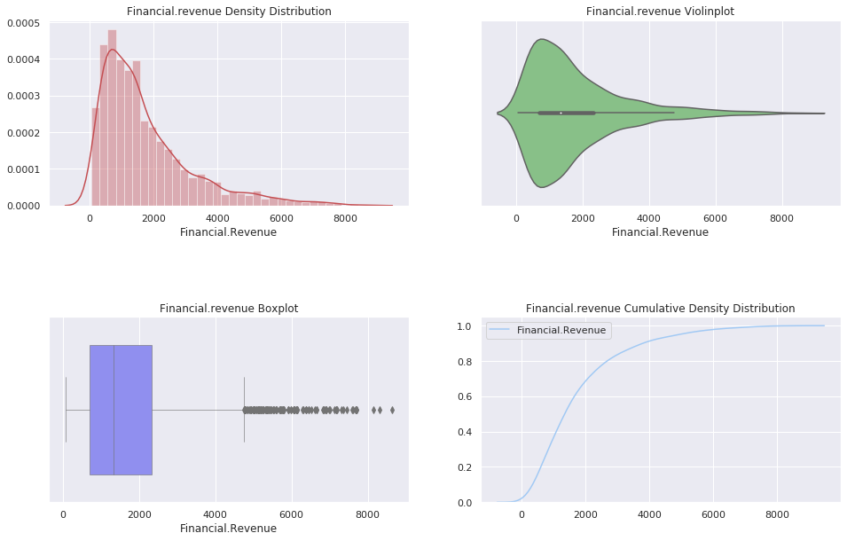

```python
summary(df,'Financial.Revenue')
```

```
5 Point Summary of Inquiries.in.the.last.6.months Attribute:
Inquiries.in.the.last.6.months(min) : 0.0
Q1                    : 0.0
Q2(Median)            : 0.0
Q3                    : 1.0
Inquiries.in.the.last.6.months(max) : 9.0
```

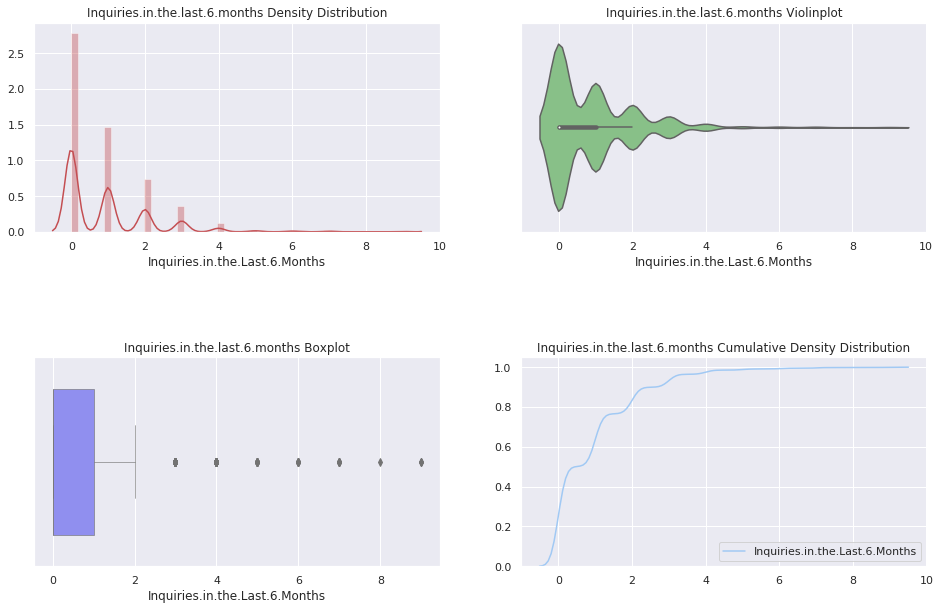

```python
summary(df,'Inquiries.in.the.Last.6.Months')
```

```
5 Point Summary of Employment.length Attribute:
Employment.length(min) : 1
Q1                    : 2.0
Q2(Median)            : 5.0
Q3                    : 10.0
Employment.length(max) : 10
```

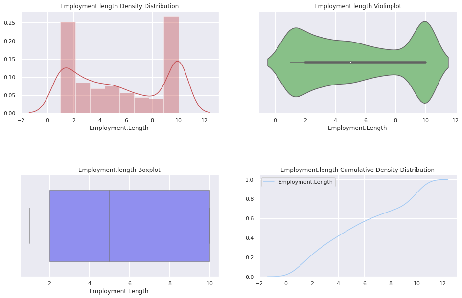

```python
summary(df,'Employment.Length')
```

```
5 Point Summary of Fico.lower Attribute:
Fico.lower(min) : 640
Q1                    : 680.0
Q2(Median)            : 700.0
Q3                    : 725.0
Fico.lower(max) : 830
```

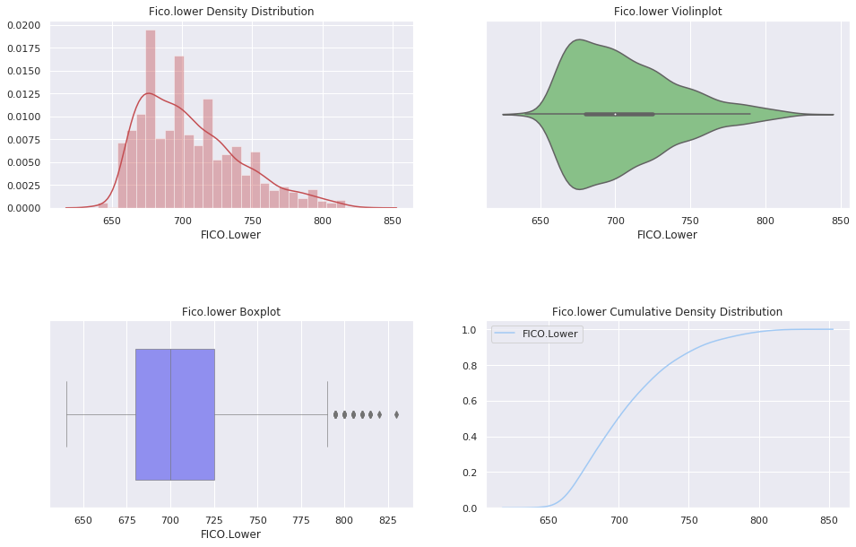

```python
summary(df,'FICO.Lower')
```

```python
scale_FICO = MinMaxScaler()
scale_Amount = MinMaxScaler()
# generación de métrica de riesgo conjunto al monto del préstamo para tener una idea de como se relacionan
df['scaled.FICO.Lower'] = scale_FICO.fit_transform(df['FICO.Lower'].values.reshape(-1, 1))
df['scaled.Amount.Requested'] = scale_Amount.fit_transform(df['Amount.Requested'].values.reshape(-1, 1))
df['Risk.Amount'] = df['scaled.Amount.Requested']*df['scaled.FICO.Lower']
```

```python
df.info()
```

```
<class 'pandas.core.frame.DataFrame'>
Int64Index: 2106 entries, 0 to 2199
Data columns (total 21 columns):
 #   Column                          Non-Null Count  Dtype
---  ------                          --------------  -----
 0   ID                              2106 non-null   object
 1   Amount.Requested                2106 non-null   int64
 2   Amount.Funded.By.Investors      2106 non-null   float64
 3   Interest.Rate                   2106 non-null   float64
 4   Loan.Length                     2106 non-null   int64
 5   Loan.Purpose                    2105 non-null   category
 6   Debt.To.Income.Ratio            2106 non-null   float64
 7   State                           2106 non-null   category
 8   Home.Ownership                  2105 non-null   category
 9   Monthly.Income                  2106 non-null   float64
 10  FICO.Range                      2106 non-null   category
 11  Open.CREDIT.Lines               2106 non-null   int64
 12  Revolving.CREDIT.Balance        2106 non-null   int64
 13  Inquiries.in.the.Last.6.Months  2106 non-null   float64
 14  Employment.Length               2106 non-null   int64
 15  Financial.Revenue               2106 non-null   float64
 16  FICO.Lower                      2106 non-null   int64
 17  FICO.Upper                      2106 non-null   int64
 18  scaled.FICO.Lower               2106 non-null   float64
 19  scaled.Amount.Requested         2106 non-null   float64
 20  Risk.Amount                     2106 non-null   float64
dtypes: category(4), float64(9), int64(7), object(1)
memory usage: 308.5+ KB
```

```
5 Point Summary of Amount.requested Attribute:
Amount.requested(min) : 1000
Q1                    : 6425.0
Q2(Median)            : 10425.0
Q3                    : 17325.0
Amount.requested(max) : 35000
```

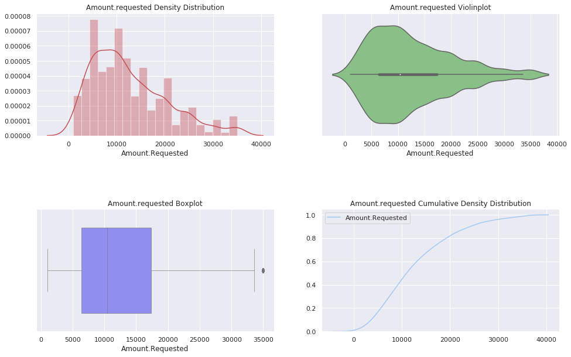

```python
summary(df,'Amount.Requested')
```

```
5 Point Summary of Risk.amount Attribute:
Risk.amount(min) : 0.0
Q1                    : 0.04179566563467493
Q2(Median)            : 0.08614551083591332
Q3                    : 0.16679566563467485
Risk.amount(max) : 0.8173374613003094
```

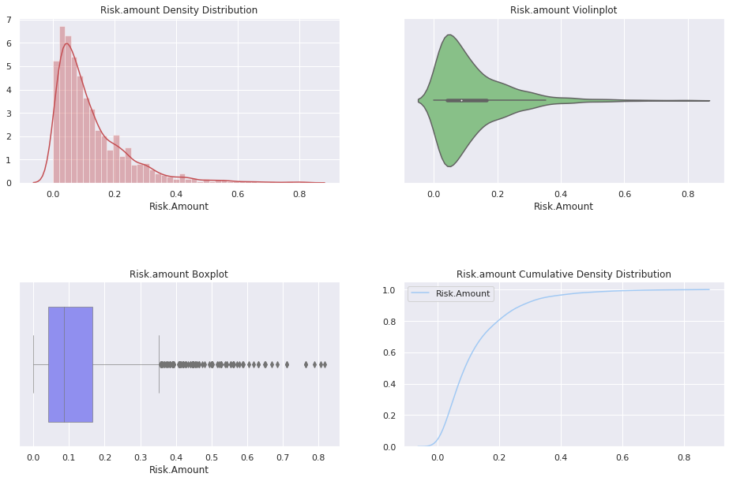

```python
summary(df,'Risk.Amount')
```

## Ejemplo de segmentación RFM

(back to top)

Del conjunto de datos actual, no tenemos la fecha en que la persona tomó el préstamo, lo que podría dar mayor información al momento de analizarlo como parte de un segmento. A modo de simular como una segmentación RFM (Recency, Frequency and Monetary Value) funciona, se generará una distribución bimodal sintética de fechas de toma de préstamo, para simular una población de clientes recientes en conjunto con otra más espaciada de clientes más antiguos

```python
# generación de rango de fechas diario y distribución bimodal a partir de normales
date_rng = pd.date_range(start='01/01/2018', end='06/02/2019', freq='D')

if len(df)%2 == 1:
    N1 = int(len(df)/2)
    N2 = N1 + 1
else:
    N1 = N2 = int(len(df)/2)
mu, sigma = 80, 15
mu2, sigma2 = 10, 30
X1 = np.random.normal(mu, sigma, N1)
X2 = np.random.normal(mu2, sigma2, N2)
X = np.concatenate([X1, X2])
```

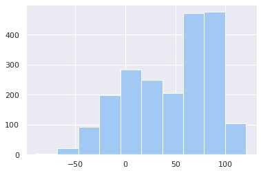

```python
plt.hist(X)
```

```python
# escalamiento de distribución bimodal en el arreglo de fecha (índices)
X_scaled = (X - X.min())/(X.max() - X.min())*len(date_rng) - 1
X_scaled = X_scaled.astype('int')
```

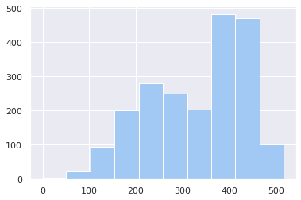

```python
plt.hist(X_scaled)
```

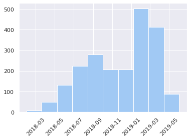

```python
# muestreo de fechas en rango de fechas
plt.hist(date_rng[X_scaled])
plt.xticks(rotation = 45)
```

```python
# agregar fechas sintéticas a dataframe
df['Loan.Date'] = date_rng[X_scaled]
```

```python
df.info()
```

```
<class 'pandas.core.frame.DataFrame'>
Int64Index: 2106 entries, 0 to 2199
Data columns (total 22 columns):
 #   Column                          Non-Null Count  Dtype
---  ------                          --------------  -----
 0   ID                              2106 non-null   object
 1   Amount.Requested                2106 non-null   int64
 2   Amount.Funded.By.Investors      2106 non-null   float64
 3   Interest.Rate                   2106 non-null   float64
 4   Loan.Length                     2106 non-null   int64
 5   Loan.Purpose                    2105 non-null   category
 6   Debt.To.Income.Ratio            2106 non-null   float64
 7   State                           2106 non-null   category
 8   Home.Ownership                  2105 non-null   category
 9   Monthly.Income                  2106 non-null   float64
 10  FICO.Range                      2106 non-null   category
 11  Open.CREDIT.Lines               2106 non-null   int64
 12  Revolving.CREDIT.Balance        2106 non-null   int64
 13  Inquiries.in.the.Last.6.Months  2106 non-null   float64
 14  Employment.Length               2106 non-null   int64
 15  Financial.Revenue               2106 non-null   float64
 16  FICO.Lower                      2106 non-null   int64
 17  FICO.Upper                      2106 non-null   int64
 18  scaled.FICO.Lower               2106 non-null   float64
 19  scaled.Amount.Requested         2106 non-null   float64
 20  Risk.Amount                     2106 non-null   float64
 21  Loan.Date                       2106 non-null   datetime64[ns]
dtypes: category(4), datetime64[ns](1), float64(9), int64(7), object(1)
memory usage: 324.9+ KB
```

```python
# referencia día actual
NOW = datetime(2019,12,24)
# agregación de campos para generar criterios RFM (notar que podríamos tener ID repetidos y esto permite individualizar a los clientes)
rfmTable = df.groupby('ID').agg({'Loan.Date': lambda x: (NOW - x.max()).days, 'Inquiries.in.the.Last.6.Months': lambda x: x.sum(), 'Risk.Amount': lambda x: x.sum()})
rfmTable['Loan.Date'] = rfmTable['Loan.Date'].astype(int)
# renombrado de columnas a RFM
rfmTable.rename(columns={'Loan.Date': 'recency',
                         'Inquiries.in.the.Last.6.Months': 'frequency',
                         'Risk.Amount': 'monetary_value'}, inplace=True)
```

```python
rfmTable.head(10)
```

| ID | recency | frequency | monetary_value |
| --- | --- | --- | --- |
| 10 | 327 | 1.0 | 0.046440 |
| 10006 | 583 | 3.0 | 0.220124 |
| 100072 | 321 | 3.0 | 0.253289 |
| 100114 | 364 | 1.0 | 0.213197 |
| 100140 | 332 | 0.0 | 0.113777 |
| 100217 | 257 | 3.0 | 0.058050 |
| 100221 | 273 | 1.0 | 0.202012 |
| 100288 | 276 | 2.0 | 0.019350 |
| 100313 | 213 | 0.0 | 0.117260 |
| 100424 | 290 | 2.0 | 0.048762 |

```python
# separación por cuartiles
quantiles = rfmTable.quantile(q=[0.25,0.5,0.75])
quantiles = quantiles.to_dict()
quantiles
```

```
{'recency': {0.25: 304.0, 0.5: 359.5, 0.75: 478.75},
 'frequency': {0.25: 0.0, 0.5: 0.0, 0.75: 1.0},
 'monetary_value': {0.25: 0.04179566563467493,
  0.5: 0.08614551083591332,
  0.75: 0.16679566563467485}}
```

```python
segmented_rfm = rfmTable
```

```python
# score de recencia (relación positiva)
def RScore(x,p,d):
    if x <= d[p][0.25]:
        return 1
    elif x <= d[p][0.50]:
        return 2
    elif x <= d[p][0.75]:
        return 3
    else:
        return 4

# score de frecuencia (relación negativa)
def FMScore(x,p,d):
    if x <= d[p][0.25]:
        return 4
    elif x <= d[p][0.50]:
        return 3
    elif x <= d[p][0.75]:
        return 2
    else:
        return 1
```

```python
# separación de cuartiles
segmented_rfm['r_quartile'] = segmented_rfm['recency'].apply(RScore, args=('recency',quantiles,))
segmented_rfm['f_quartile'] = segmented_rfm['frequency'].apply(FMScore, args=('frequency',quantiles,))
segmented_rfm['m_quartile'] = segmented_rfm['monetary_value'].apply(FMScore, args=('monetary_value',quantiles,))
segmented_rfm.head()
```

| ID | recency | frequency | monetary_value | r_quartile | f_quartile | m_quartile |
| --- | --- | --- | --- | --- | --- | --- |
| 10 | 327 | 1.0 | 0.046440 | 2 | 2 | 3 |
| 10006 | 583 | 3.0 | 0.220124 | 4 | 1 | 1 |
| 100072 | 321 | 3.0 | 0.253289 | 2 | 1 | 1 |
| 100114 | 364 | 1.0 | 0.213197 | 3 | 2 | 1 |
| 100140 | 332 | 0.0 | 0.113777 | 2 | 4 | 2 |

```python
# cálculo de score
segmented_rfm['RFMScore'] = segmented_rfm.r_quartile.map(str) + segmented_rfm.f_quartile.map(str) + segmented_rfm.m_quartile.map(str)
segmented_rfm.head()
```

| ID | recency | frequency | monetary_value | r_quartile | f_quartile | m_quartile | RFMScore |
| --- | --- | --- | --- | --- | --- | --- | --- |
| 10 | 327 | 1.0 | 0.046440 | 2 | 2 | 3 | 223 |
| 10006 | 583 | 3.0 | 0.220124 | 4 | 1 | 1 | 411 |
| 100072 | 321 | 3.0 | 0.253289 | 2 | 1 | 1 | 211 |
| 100114 | 364 | 1.0 | 0.213197 | 3 | 2 | 1 | 321 |
| 100140 | 332 | 0.0 | 0.113777 | 2 | 4 | 2 | 242 |

```python
# TOP TEN de clientes
segmented_rfm[segmented_rfm['RFMScore']=='111'].sort_values('monetary_value', ascending=False).head(10)
```

| ID | recency | frequency | monetary_value | r_quartile | f_quartile | m_quartile | RFMScore |
| --- | --- | --- | --- | --- | --- | --- | --- |
| 37041 | 262 | 3.0 | 0.763158 | 1 | 1 | 1 | 111 |
| 40489 | 302 | 2.0 | 0.668731 | 1 | 1 | 1 | 111 |
| 60151 | 304 | 3.0 | 0.561146 | 1 | 1 | 1 | 111 |
| 98787 | 220 | 2.0 | 0.414474 | 1 | 1 | 1 | 111 |
| 32601 | 303 | 3.0 | 0.383901 | 1 | 1 | 1 | 111 |
| 67672 | 279 | 3.0 | 0.333340 | 1 | 1 | 1 | 111 |
| 2807 | 230 | 5.0 | 0.323529 | 1 | 1 | 1 | 111 |
| 80041 | 255 | 2.0 | 0.302632 | 1 | 1 | 1 | 111 |
| 45525 | 288 | 3.0 | 0.302632 | 1 | 1 | 1 | 111 |
| 13181 | 261 | 2.0 | 0.297214 | 1 | 1 | 1 | 111 |

```python
# parsing de rfm score a variable numérica que suma de manera equivalente cada valoración de segmento
df = pd.merge(df,segmented_rfm['RFMScore'].reset_index(),on='ID')
df['RFMScore'] = df['RFMScore'].astype('category')
df['RFMScore.Sum'] = df['RFMScore'].apply(lambda x: int(x[0])+int(x[1])+int(x[2]))
```

```python
df.info()
```

```
<class 'pandas.core.frame.DataFrame'>
Int64Index: 2106 entries, 0 to 2105
Data columns (total 24 columns):
 #   Column                          Non-Null Count  Dtype
---  ------                          --------------  -----
 0   ID                              2106 non-null   object
 1   Amount.Requested                2106 non-null   int64
 2   Amount.Funded.By.Investors      2106 non-null   float64
 3   Interest.Rate                   2106 non-null   float64
 4   Loan.Length                     2106 non-null   int64
 5   Loan.Purpose                    2105 non-null   category
 6   Debt.To.Income.Ratio            2106 non-null   float64
 7   State                           2106 non-null   category
 8   Home.Ownership                  2105 non-null   category
 9   Monthly.Income                  2106 non-null   float64
```

[output cut: 16 more lines]

### Algunas visualizaciones de RFM

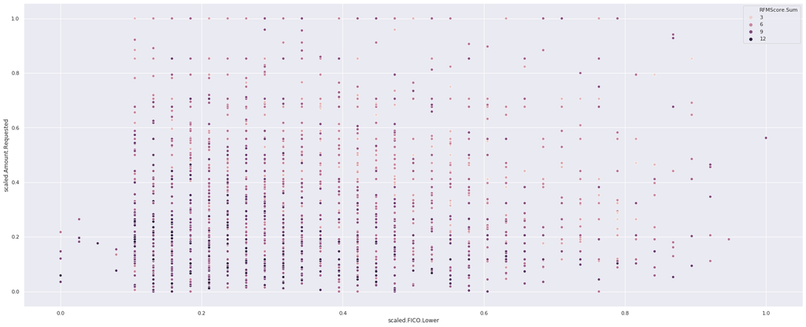

```python
# distribución rfm sobre monto y riesgo
plt.figure(figsize=(30,12))
sns.scatterplot(data=df,x='scaled.FICO.Lower',y='scaled.Amount.Requested',hue='RFMScore.Sum')
```

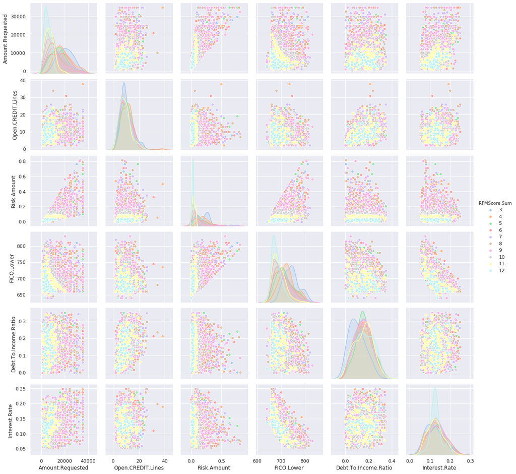

```python
# comportamiento de algunos campos con respecto al score RFM
select_columns = ['Amount.Requested','Open.CREDIT.Lines','Risk.Amount','FICO.Lower','Debt.To.Income.Ratio','RFMScore.Sum','Interest.Rate']
plt.figure(figsize=(30,12))
sns.pairplot(data=df[select_columns],hue='RFMScore.Sum')
```

## Codificación de variables categóricas

(back to top)

```python
# enfoque target encoder
#!pip install category-encoders
# import category_encoders as ce
# target_encoder = ce.TargetEncoder(cols = categorical_cols)
# X_train = target_encoder.fit_transform(X_train, y_train)
# X_train.shape
```

```python
# enfoque get_dummies, no funciona para poder replicar o guardar objeto de categorización
#df = pd.concat([df,pd.get_dummies(df[OneHotCols],drop_first=True)],axis=1)
```

```python
categorical_cols = set(df.select_dtypes('category').columns)
# aquí FICO es ordinal, y será evaluada del procesamiento de la cota inferior, así que la restamos de las categóricas
OneHotCols = categorical_cols - set(['FICO.Range'])
# verificar que no existen nans en columnas categóricas
df.dropna(subset=OneHotCols,inplace=True)
cat_encoder = OneHotEncoder(sparse = False, handle_unknown = 'ignore')
encoded_vars_train = pd.DataFrame(cat_encoder.fit_transform(df[OneHotCols]))
numeric_vars_train = df.drop(OneHotCols, axis = 1).reset_index()
df = pd.concat([numeric_vars_train, encoded_vars_train], axis = 1)
dump(cat_encoder,'cat_encoder.joblib')
```

```
['cat_encoder.joblib']
```

```python
df.info()
```

```
<class 'pandas.core.frame.DataFrame'>
RangeIndex: 2104 entries, 0 to 2103
Columns: 132 entries, index to 110
dtypes: category(1), datetime64[ns](1), float64(120), int64(9), object(1)
memory usage: 2.1+ MB
```

## Tabla final

(back to top)

```python
df_train, df_val = train_test_split(df, test_size=0.33, random_state=42)
```

```python
# aquí se excluyen columnas que no tienen valor predictivo, están correlacionadas con el target, se reemplazaron por encoding, o no se usarán en el modelado
columns_to_exclude = ['ID','Amount.Funded.By.Investors','FICO.Range','Financial.Revenue','Fico.Upper','Loan.Date',
                      'scaled.FICO.Lower','scaled.Amount.Requested','Risk.Amount','RFMScore','RFMScore.Sum',
                      'Interest.Rate'] + list(categorical_cols)
```

```python
X_train = df_train[df_train.columns.difference(columns_to_exclude)]
y_train = df_train['Interest.Rate']

X_val = df_val[df_val.columns.difference(columns_to_exclude)]
y_val = df_val['Interest.Rate']
```

### Prueba de modelo interno

```python
clf = RandomForestRegressor()
```

```python
clf.fit(X_train,y_train)
```

```
RandomForestRegressor(bootstrap=True, ccp_alpha=0.0, criterion='mse',
                      max_depth=None, max_features='auto', max_leaf_nodes=None,
                      max_samples=None, min_impurity_decrease=0.0,
                      min_impurity_split=None, min_samples_leaf=1,
                      min_samples_split=2, min_weight_fraction_leaf=0.0,
                      n_estimators=100, n_jobs=None, oob_score=False,
                      random_state=None, verbose=0, warm_start=False)
```

```python
y_pred = clf.predict(X_val)
```

```python
r2_score(y_true = y_val, y_pred = y_pred)
```

```
0.7813906266154501
```

```python
mean_absolute_error(y_true = y_val, y_pred = y_pred)
```

```
0.01409956573299819
```

```python
mean_squared_error(y_true = y_val, y_pred = y_pred)
```

```
0.0003752282975159882
```

```python
explained_variance_score(y_true = y_val, y_pred = y_pred)
```

```
0.7829242414551364
```

### Subida de datos a bucket en S3

```python
# definir el bucket en S3 donde guardaremos los datos del modelo
bucket = sagemaker.Session().default_bucket()
# bucket = 'IBK-ojedaiva'
prefix = 'IBK-mockup'
sess = sagemaker.session.Session(default_bucket= 's3://{}'.format(bucket))
role = sagemaker.get_execution_role()
output_path = 's3://{}/{}/data'.format(bucket, prefix)
```

```python
# definir rutas de datos dentro de bucket
train_fname = "{}/train/train.csv".format(output_path)
val_fname = "{}/validation/validation_set.csv".format(output_path)

pd.concat([y_train,X_train],axis=1, ignore_index=True).to_csv(train_fname, header = False, index= False)
pd.concat([y_val,X_val],axis=1, ignore_index=True).to_csv(val_fname, header = False, index= False)
```

```python
print('Datos guardados en')
print(train_fname)
print(val_fname)
```

```
Datos guardados en
s3://sagemaker-us-east-1-189229688351/IBK-mockup/data/train/train.csv
s3://sagemaker-us-east-1-189229688351/IBK-mockup/data/validation/validation_set.csv
```

```python
1+1
```

```
2
```